# Covid-19 Effect on Institutional Performance

Rodrigo

2023-04-30

# Summary

This project is a condensed public version of my analysis for the Ministry of Education of Peru (Minedu) in 2021, which was conducted while my team and I designed the 2022 edition of a Results Based Financing (RBF) Program called “Compromisos de Desempeño” (CdD or Performance Commitments). The aim of the analysis was to investigate how the Covid-19 pandemic affected institutional performance, specifically in the education sector in Peru.

The public education sector in Peru is under the governance of the Ministry of Education (Minedu) at the national level. However, 26 Regional Offices and 222 Local Education Management Units (UGELs or Unidades de Gestión Educativa Local) are responsible for various functions and responsibilities, such as enrolling students, hiring teachers, distributing books, addressing bullying and violence cases, among others.

For more information on the public education sector in Peru, please refer to the appendix.

## Data Used

*How to measure Institutional Performance?* The historical data of CdD results contain the average achievement value or “Valor Logrado” for each evaluated indicator in every UGEL or jurisdiction. These results can be analyzed by year and phase. For example, during phase 1 of the CdD 2020 on January 31st, 2020, Minedu assessed eight indicators among 223 institutions. You can find these results on the CdD Program’s website (http://www.minedu.gob.pe/cdd/).

*How to measure the severity of the pandemic in each jurisdiction?* I chose to utilize the number of Covid-19 related deaths per 1,000 people in each jurisdiction for every quarter between 2020 and 2021. This decision was made due to the belief that this data provides a more accurate representation of the impact of Covid-19 on the country, as Covid-19 infections may have been under reported due to limited testing availability, particularly during the initial stages of the pandemic. It is worth noting that Peru has been transparent in releasing pandemic data, which can be accessed through the “Datos Abiertos” (Open Data) webpage (https://www.datosabiertos.gob.pe/dataset/fallecidos-por-covid-19-ministerio-de-salud-minsa).

*Other data used* In order to associate districts to UGEL jurisdictions and to better characterize each UGEL, we required more data about the UGELs. For this purpose, I used the education census of 2020, which can be found at https://escale.minedu.gob.pe/uee/-/document_library_display/GMv7/view/6226837. Additionally, we needed to obtain estimates of Peru’s population for 2021, as this was the only available dataset in the “Datos Abiertos” (Open Data) web page, which can be accessed at https://www.datosabiertos.gob.pe/dataset/población-peru.

## Results

Based on the results, there was a significant impact of Covid-19 on UGELs performance in Peru in the first wave of 2020, particularly in areas that were hit harder by the pandemic. However, our analysis of the second wave in 2021 suggests that institutions may have adapted to the pandemic, and that there may have been underlying factors contributing to performance reduction.

# Data processing

## Minedu data about schools in Peru

Education Census of 2020. https://escale.minedu.gob.pe/uee/-/document_library_display/GMv7/view/6226837

```r
#Importing the data from the link as an Excel because there were some character barriers using the DBF format
setwd(f_base)
peru_schools_full_df <- read_excel("padron.xlsx") %>%
  as.data.frame()

#Data cleaning
peru_schools <- peru_schools_full_df %>%
  mutate(codmod = as.numeric(COD_MOD),
         codlocal = as.numeric(CODLOCAL),
         ubigeo = as.numeric(CODGEO),
         codooii = as.numeric(CODOOII),
         level_of_education = case_when(
           NIV_MOD %in% c("A1", "A2", "A3","A4") ~ "Preschool",
           NIV_MOD == "B0" ~ "Primary school",
           NIV_MOD == "F0" ~ "Secondary school",
           NIV_MOD %in% c("D1", "D2") ~ "Alternative school",
           NIV_MOD %in% c("E0","E1", "E2") ~ "Special needs school",
           NIV_MOD %in% c("K0","L0", "M0","T0") ~ "Higher education - not universities"),
         n_schools = 1,
         region = str_to_title(DPTO),
         region = ifelse(region == "Madre De Dios", "Madre de Dios", region),
         region = ifelse(region == "San Martin", "San Martín", region),
         region = ifelse(region == "Junin", "Junín", region),
         region = ifelse(region == "Huanuco", "Huánuco", region),
         region = ifelse(region == "Apurimac", "Apurímac", region),
         region = ifelse(region == "Ancash", "Áncash", region)) %>%
  filter(ANEXO ==0,
         D_FORMA == "Escolarizada",
         level_of_education != "Higher education - not universities") %>%
  rename(school_name = CEN_EDU,
         management = D_GESTION,
         urban_context = DAREAMED,
         geography = REGION_NAT,
         latitud = NLAT_IE,
         longitud = NLONG_IE,
         elevation_msnm = ALTITUD,
         ugel = DRE_UGEL) %>%
  select(region,ugel,codmod,codlocal,ubigeo,codooii,level_of_education,school_name,management,urban_context,geography,latitud,longitud,elevation_msnm,n_schools)


#Number of districts in Peru
paste0("Number of districts in Peru: ",length(unique(peru_schools$ubigeo)))
```

```
## [1] "Number of districts in Peru: 1874"
```

```r
#Number of UGEL in Peru
paste0("Number of UGELs in Peru: ",length(unique(peru_schools$codooii)))
```

```
## [1] "Number of UGELs in Peru: 223"
```

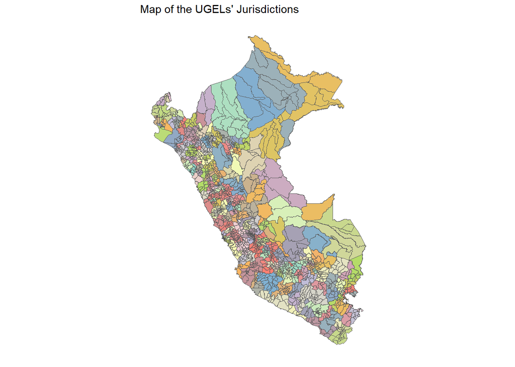

```r
#Ubigeo - Codooii relation
ubigeo_codooii <- peru_schools %>%
  group_by(codooii,ubigeo) %>%
  summarise(n_schools = n(),
            ugel = first(ugel))
write_xlsx(ubigeo_codooii,"ubigeo_codooii.xlsx")

ubigeo_codooii <- ubigeo_codooii %>%
  group_by(ubigeo) %>%
  arrange(desc(n_schools)) %>%
  slice(1) %>%
  ungroup()

#Map of UGEL
ugel_map_data <- map_DIST %>%
  mutate(ubigeo = as.numeric(COD_DISTRITO),
         region = DEPARTAMENTO) %>%
  select(c(ubigeo,region,coords_x,coords_y,geometry))

ugel_map_data <- merge(ugel_map_data,ubigeo_codooii) %>%
  mutate(ugel = str_replace(ugel, "\\d+", ""),
         ugel = gsub("  ", " ",ugel))

myPalette <- colorRampPalette(brewer.pal(8, "Set3"))(223)
ugel_map <- ggplot(ugel_map_data, aes(geometry=geometry,fill = as.character(ugel)),linewidth = 0.01) +
  geom_sf() +
  scale_fill_manual(values = myPalette, guide = FALSE) +
  theme_map() +
  labs(title = "Map of the UGELs' Jurisdictions")
ugel_map
```

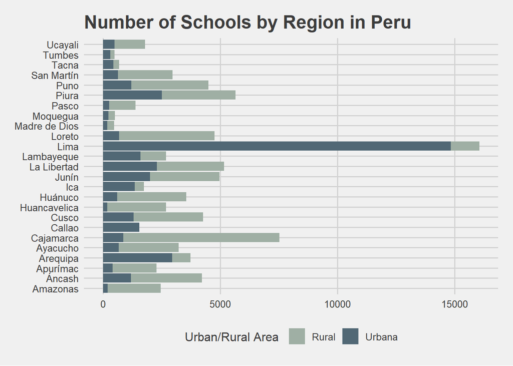

```r
ggsave("ugel_map.png", plot = ugel_map, width = 3, height = 5, dpi = 300)

#Number of schools in urban and rural areas, by region of Peru
schools_chart <- ggplot(data = peru_schools, aes(x = n_schools, y = reorder(region, n_schools), fill =  urban_context)) +
  geom_bar(stat = "identity") +
  theme_fivethirtyeight() +
  scale_fill_manual(values = rColors) +
  labs(title = "Number of Schools by Region in Peru",
       x = "Region",
       y = "Number of Schools",
       fill = "Urban/Rural Area ")
schools_chart
```

```r
ggsave("schools_chart.png", plot = schools_chart, width = 8, height = 5, dpi = 300)
```

We will use the additional module of the Censo Educativo to collect the number of students enrolled in each school district. Additionally, I used the Education Census to construct more variables to better characterize each UGEL.

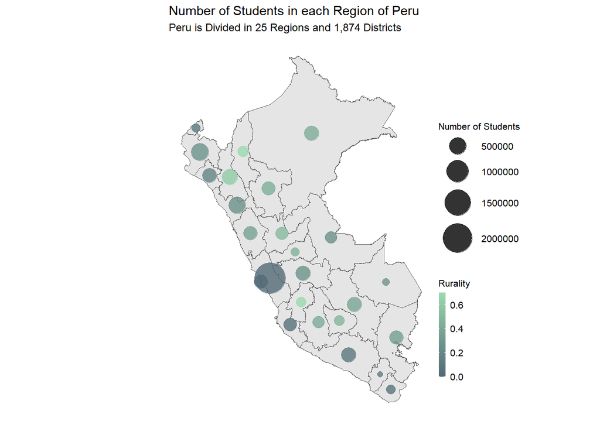

```r
#Number of students
setwd(f_base)
students <- read.dbf("Matricula_01.dbf", as.is = TRUE) %>%
  as.data.frame() %>%
  mutate(codmod = as.numeric(COD_MOD),
         codooii = as.numeric(CODOOII),
         n_students = rowSums(select(., starts_with("D")))) %>%
  group_by(codmod, codooii) %>%
  summarise(n_students = sum(n_students))


# Additional data from the census
ugel_vars <- merge(peru_schools,students,by=c("codmod","codooii"), all.x = T) %>%
  mutate(rural_strudents = ifelse(urban_context =="Rural",n_students,0)) %>%
  group_by(codooii) %>%
  summarise(region = first(region),
            n_students = sum(n_students),
            rural_strudents = sum(rural_strudents,na.rm = T),
            rurality = sum(rural_strudents)/sum(n_students),
            mean_elevation_msnm = mean(elevation_msnm),
            n_schools = n(),
            prcnt_andes = sum(geography=="SIERRA")/n(),
            prcnt_selva = sum(geography=="SELVA")/n())

#Visualizacion
geom_peru <- map_DEP %>%
  rename(region = DEPARTAMENTO)

map_data <- ugel_vars %>%
  group_by(region) %>%
  summarise(n_students = sum(n_students),
            rurality = sum(rural_strudents)/sum(n_students))
map_data <- merge(geom_peru, map_data, by = "region")


peru_map <- ggplot(map_data, aes(geometry=geometry)) +
  geom_sf(aes()) +
  theme_map() +
  geom_point(data = map_data, aes(x = coords_x, y = coords_y, size = n_students, color = rurality), alpha = 0.8) +
  scale_color_gradient(low = "#516875", high = "#9adbae") +
  scale_size(range = c(2, 12)) +
  labs(title = "Number of Students in each Region of Peru",
       subtitle = "Peru is Divided in 25 Regions and 1,874 Districts",
       size = "Number of Students",
       color = "Rurality") +
  theme(legend.position = c(1, 0.1), legend.key.width = unit(0.2, "cm"),
        legend.key.height = unit(.5, "cm"), legend.text = element_text(size = 8),
        legend.title = element_text(size = 8))
peru_map
```

```r
ggsave("peru_map.png", plot = peru_map, width = 8, height = 5, dpi = 300)
```

## Compromisos de Desempeño (CdD) results

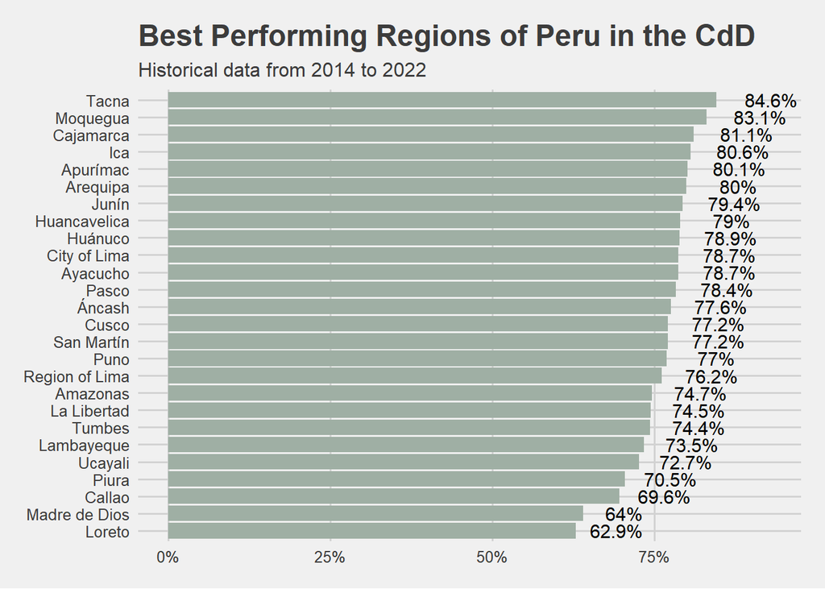

```r
#The source of the phases dates comes from the legal documents and directives on the web page
setwd(f_base)
phases_cdd <- read_excel("cdd_phase_date.xlsx") %>%
  as.data.frame()

#Results as available on the web page (validation made in-house by the team)
cdd_results <-  read.csv("resultados_hist_cdd.csv") %>%
  as.data.frame() %>%
  filter(tipo_entidad == "UGEL EJECUTORA" | tipo_entidad =="UGEL OPERATIVA" | iged =="DRE CALLAO")
cdd_results <- merge(cdd_results,phases_cdd,by = c("periodo","tramo")) %>%
  rename(year = periodo,
         phase = tramo,
         ugel = iged) %>%
  mutate(region = str_to_title(region),
         region = ifelse(region == "Madre De Dios", "Madre de Dios", region),
         region = ifelse(region == "San Martin", "San Martín", region),
         region = ifelse(region == "Junin", "Junín", region),
         region = ifelse(region == "Huanuco", "Huánuco", region),
         region = ifelse(region == "Apurimac", "Apurímac", region),
         region = ifelse(region == "Ancash", "Áncash", region),
         region = ifelse(region == "Lima Metropolitana", "City of Lima", region),
         region = ifelse(region == "Lima Provincias", "Region of Lima", region))

#Best Perforing Regions Historically
cdd_historical_chart <- cdd_results %>%
  group_by(region) %>%
  summarise(cdd_result_value = mean(valor_logrado_ufd,na.rm = T)) %>%
  ggplot(aes(x = cdd_result_value, y = reorder(region, cdd_result_value), fill = cdd_result_value)) +
  geom_bar(stat = "identity", fill = "#9fafa4") +
  theme_fivethirtyeight() +
  scale_x_continuous(labels = percent_format(accuracy = 1)) +
  labs(title = "Best Performing Regions of Peru in the CdD",
       subtitle = "Historical data from 2014 to 2022",
       x = "Mean Achievement Value",
       y = "Regions") +
  geom_text(aes(label = paste0(round(cdd_result_value*100, 1), "%")),
            position = position_stack(vjust = 1.1),
            color = "black", size = 4)

cdd_historical_chart
```

```r
ggsave("cdd_historical_chart.png", plot = cdd_historical_chart, width = 8, height = 8, dpi = 300)
```

## Ministerio de Salud data about Covid-19 related deaths in Peru

https://www.datosabiertos.gob.pe/dataset/fallecidos-por-covid-19-ministerio-de-salud-minsa I’m going to group covid deaths by quarter and year for simplicity in the analysis.

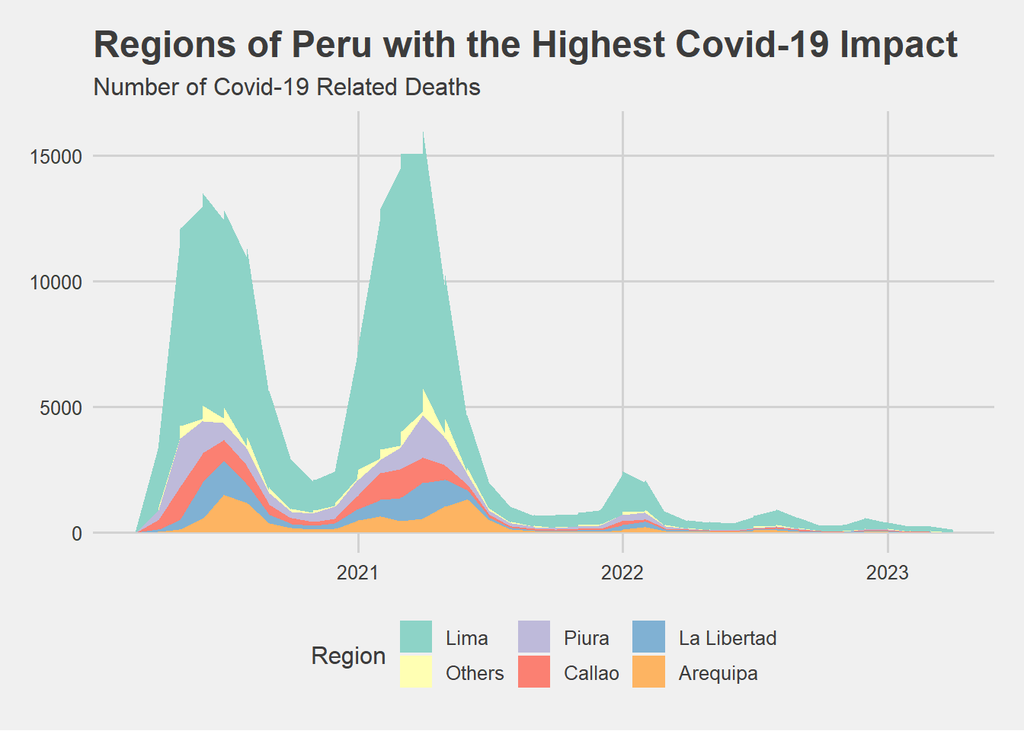

```r
setwd(f_base)
covid_deaths <- read.csv("fallecidos_covid.csv",sep = ";") %>%
  as.data.frame() %>%
  mutate(year = as.integer(substr(FECHA_FALLECIMIENTO, 1, 4)),
         month = as.integer(substr(FECHA_FALLECIMIENTO, 5, 6)),
         ubigeo = as.numeric(UBIGEO),
         age = EDAD_DECLARADA) %>%
  filter(!is.na(ubigeo))

# Visualization
timeline_covid_data <- covid_deaths %>%
  mutate(region = str_to_title(DEPARTAMENTO),
         region = ifelse(region == "Madre De Dios", "Madre de Dios", region),
         region = ifelse(region == "San Martin", "San Martín", region),
         region = ifelse(region == "Junin", "Junín", region),
         region = ifelse(region == "Huanuco", "Huánuco", region),
         region = ifelse(region == "Apurimac", "Apurímac", region),
         region = ifelse(region == "Ancash", "Áncash", region)) %>%
  group_by(year,month,region) %>%
  summarise(covid_deaths = n())

top_5_hit_regions <- timeline_covid_data %>%
  group_by(region) %>%
  summarise(total_covid_deaths = sum(covid_deaths)) %>%
  arrange(desc(total_covid_deaths)) %>%
  slice_head(n = 5) %>%
  pull(region)

timeline_covid_data$region_group <- ifelse(timeline_covid_data$region %in% top_5_hit_regions,
                                           timeline_covid_data$region, "Others")

covid_timeline <- timeline_covid_data %>%
  mutate(date = ymd(paste(year, month, "01", sep = "-")),
         covid_deaths = ifelse(is.na(covid_deaths),0,covid_deaths),
         region_group = reorder(region_group, -covid_deaths)) %>%
  ggplot(aes(x = date, y = covid_deaths, fill = region_group)) +
  geom_area(position = "stack") +
  scale_fill_brewer(palette = "Set3") +
  theme_fivethirtyeight() +
  labs(title = "Regions of Peru with the Highest Covid-19 Impact",
       subtitle = "Number of Covid-19 Related Deaths",
       x = "Time",
       y = "Number of Deaths",
       fill = "Region")
covid_timeline
```

```r
ggsave("covid_timeline.png", plot = covid_timeline, width = 12, height = 8, dpi = 300)



#Grouping covid deaths by quarter for simplicity
covid_deaths_ubigeo <- covid_deaths %>%
  group_by(ubigeo) %>%
  summarise(covid_deaths_2020_1 = sum(year==2020 & month <=3),
            covid_deaths_2020_2 = sum(year==2020 & month >3 & month<=6),
            covid_deaths_2020_3 = sum(year==2020 & month >6 & month<=9),
            covid_deaths_2020_4 = sum(year==2020 & month >9),
            covid_deaths_2021_1 = sum(year==2021 & month <=3),
            covid_deaths_2021_2 = sum(year==2021 & month >3 & month<=6),
            covid_deaths_2021_3 = sum(year==2021 & month >6 & month<=9),
            covid_deaths_2021_4 = sum(year==2021 & month >9),
            covid_deaths = n())

total_deaths <- as.numeric(sum(timeline_covid_data$covid_deaths))
print(paste0("Covid-19 related deaths in Peru: ",total_deaths))
```

```
## [1] "Covid-19 related deaths in Peru: 219986"
```

Timeline of Covid and UGELs performance

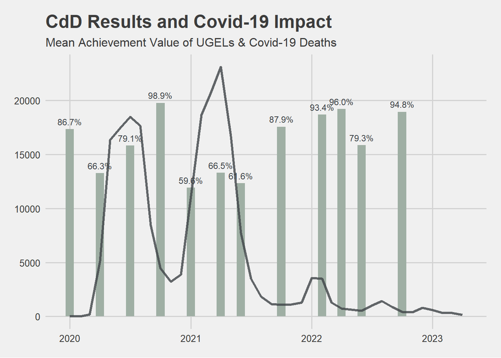

```r
timeline_cdd <- cdd_results %>%
  filter(year > 2019) %>%
  mutate(month = mes_corte) %>%
  group_by(year,month) %>%
  summarise(cdd_result_value = mean(valor_logrado_ufd,na.rm = T))

timeline_covid <- covid_deaths %>%
  group_by(year,month) %>%
  summarise(covid_deaths = n())

#Timeline
timeline <- merge(timeline_covid, timeline_cdd, by = c("year","month"),all = T) %>%
  add_row(year = 2020, month = 2) %>%
  mutate(date = ymd(paste(year, month, "01", sep = "-")),
         cdd_result_value = ifelse(is.na(cdd_result_value),0,cdd_result_value),
         covid_deaths = ifelse(is.na(covid_deaths),0,covid_deaths))

timelinechart <- ggplot(timeline, aes(x = date)) +
  geom_bar(aes(y = cdd_result_value * 20000), stat = "identity", fill = "#9fafa4") +
  geom_line(aes(y = covid_deaths),color = "#3d4246",alpha = .8,size = 1.2) +
  theme_fivethirtyeight() +
  labs(title = "CdD Results and Covid-19 Impact",
       subtitle = "Mean Achievement Value of UGELs & Covid-19 Deaths",
       x = "Phases of the CdD",
       y = "Number of Covid-19 Deaths",
       fill = "Achievment Value",
       color = "Number of Covid-19 Deaths") +
  geom_text(data = subset(timeline, cdd_result_value > 0),
            aes(y = (cdd_result_value + .035) * 20000, label = paste0(scales::percent(cdd_result_value, accuracy = 0.1))),
            hjust = 0.5, size = 3, color = "#3d4246")

timelinechart
```

```r
ggsave("timelinechart.png", plot = timelinechart, width = 14, height = 8, dpi = 300)
```

As we can see, the two waves of the pandemic in Peru coincide with reductions in the performance of the UGELs in the CdD, meaning a performance dip in both cases. The first Covid-19 case in Peru was reported in March 2020, by this time, Minedu had already evaluated 8 indicators in the phase 1 of the CdD 2020. This event, gives us the possibility to see how the UGELs would have performed on normal conditions.

It’s important to remember that the indicators evaluated in each phase fo the CdD are different, depending on the design of the program, so comparison is not 100% accurate. Nevertheless, it is valuable to see if there is any correlation between the mean achievement value and Covid-19 related deaths in the jurisdiction, for each UGEL.

# Analysis

I will analyze how these tough quarters for Peru, in regards of Covid-19 impact, affected the performance of the UGELs, measured as the mean achievement value of each institution on the indicators evaluated in each phase. I will perform some simple correlation analysis, as well as some linear regression analysis.

## Correlation analysis

- Correlation of the mean achievement value (phases 2 and 3 of 2020) vs Covid-19 related deaths (quarters 2 and 3 of 2020).
- Correlation of the mean achievement value (phases 1 and 2 of 2021) Covid-19 related deaths (quarters 1 and 2 of 2021).
- Covid hit: Correlation and linear regression of (phase 1 2020 - mean vachievement value of phases 2 and 3) vs Covid-19 related deaths (quarters 2 and 3 of 2020).

### Final Data Preparations

I used data from INEI (Equivalent to a Census Bureau in Peru) to collect estimated data of the population. This way, I can express the Covid-19 related deaths relative to each jurisdiction population.

```r
setwd(f_base)
#Population in Peru
peru_population <- read.csv("TB_POBLACION_INEI.csv",sep = ",") %>%
  as.data.frame() %>%
  mutate(ubigeo = ubigeo_inei) %>%
  group_by(ubigeo) %>%
  summarise(population = sum(Cantidad))

sum(peru_population$population)
```

```
## [1] 32526084
```

```r
df_list <- list(covid_deaths_ubigeo, peru_population, ubigeo_codooii)
covid_deaths_pops <- df_list %>% reduce(full_join, by="ubigeo")

#Now we need to calculate how many Covid-19 related death occurred in every UGEL jurisdiction, as well as the population of each jurisdiction
# Also we want to analyze covid deaths relative to jurisdiction population. I chose covid deaths per 1k inhabitants.
covid_deaths_ugel <- covid_deaths_pops %>%
  group_by(codooii) %>%
  summarise(covid_deaths_2020_1 = 1000*sum(covid_deaths_2020_1,na.rm = T)/sum(population),
            covid_deaths_2020_2 = 1000*sum(covid_deaths_2020_2,na.rm = T)/sum(population),
            covid_deaths_2020_3 = 1000*sum(covid_deaths_2020_3,na.rm = T)/sum(population),
            covid_deaths_2020_4 = 1000*sum(covid_deaths_2020_4,na.rm = T)/sum(population),
            covid_deaths_2021_1 = 1000*sum(covid_deaths_2021_1,na.rm = T)/sum(population),
            covid_deaths_2021_2 = 1000*sum(covid_deaths_2021_2,na.rm = T)/sum(population),
            covid_deaths_2021_3 = 1000*sum(covid_deaths_2021_3,na.rm = T)/sum(population),
            covid_deaths_2021_4 = 1000*sum(covid_deaths_2021_4,na.rm = T)/sum(population),
            covid_deaths = sum(covid_deaths,na.rm = T),
            population = sum(population))

# Mean achievement value by year and phase from 2020 to 2021, we will call this variables vl_*
cdd_results_ugel <- cdd_results %>%
  filter(year == 2020 | year == 2021) %>%
  group_by(codooii) %>%
  summarise(ugel = first(ugel),
            vl_2020_1 = mean(valor_logrado_ufd[year==2020 & phase==1],na.rm = T),
            vl_2020_2 = mean(valor_logrado_ufd[year==2020 & phase==2],na.rm = T),
            vl_2020_2_3 = mean(valor_logrado_ufd[year==2020 & (phase==2 | phase==3)],na.rm = T),
            vl_2020_4 = mean(valor_logrado_ufd[year==2020 & phase==4],na.rm = T),
            vl_2021_1_2 = mean(valor_logrado_ufd[year==2021 & (phase==1 | phase==2)],na.rm = T),
            vl_2021_3 = mean(valor_logrado_ufd[year==2021 & phase==3],na.rm = T))


#We need to merge these three dataframes by codooii
df_list2 <- list(cdd_results_ugel, covid_deaths_ugel, ugel_vars)
analysis_df <- df_list2 %>% reduce(full_join, by="codooii")
head(analysis_df)
```

```
## # A tibble: 6 × 26
##   codooii ugel   vl_2020_1 vl_2020_2 vl_2020_2_3 vl_2020_4 vl_2021_1_2 vl_2021_3
##     <dbl> <chr>      <dbl>     <dbl>       <dbl>     <dbl>       <dbl>     <dbl>
## 1   10001 UGEL …     0.838     0.37        0.620   NaN           0.725     0.646
## 2   10002 UGEL …     0.923     0.675       0.721     0.969       0.860     0.683
## 3   10003 UGEL …     0.919     0.368       0.626   NaN           0.703     0.678
## 4   10004 UGEL …     0.767     0.701       0.689     0.986       0.546     0.628
## 5   10005 UGEL …     0.868     0.388       0.639   NaN           0.4       0.602
## 6   10006 UGEL …     0.875     0.368       0.627   NaN           0.746     0.78
## # ℹ 18 more variables: covid_deaths_2020_1 <dbl>, covid_deaths_2020_2 <dbl>,
## #   covid_deaths_2020_3 <dbl>, covid_deaths_2020_4 <dbl>,
## #   covid_deaths_2021_1 <dbl>, covid_deaths_2021_2 <dbl>,
## #   covid_deaths_2021_3 <dbl>, covid_deaths_2021_4 <dbl>, covid_deaths <int>,
## #   population <int>, region <chr>, n_students <dbl>, rural_strudents <dbl>,
## #   rurality <dbl>, mean_elevation_msnm <dbl>, n_schools <int>,
## #   prcnt_andes <dbl>, prcnt_selva <dbl>
```

```r
#Regions with the higher population in Peru:
analysis_df %>%
  group_by(region) %>%
  summarise(population = sum(population),
            rurality = sum(rural_strudents)/sum(n_students),
            covid_deaths = sum(covid_deaths)) %>%
  arrange(desc(population)) %>%
  slice_head(n = 10)
```

```
## # A tibble: 10 × 4
##    region      population rurality covid_deaths
##    <chr>            <int>    <dbl>        <int>
##  1 Lima          10458367   0.0210        97113
##  2 La Libertad    1956389   0.262         11049
##  3 Piura          1888605   0.269         13129
##  4 Cajamarca      1543104   0.611          4618
##  5 Puno           1471405   0.343          4851
##  6 Junín          1389850   0.266          7631
##  7 Arequipa       1350676   0.0972        10635
##  8 Cusco          1346373   0.384          5299
##  9 Lambayeque     1300720   0.173          9488
## 10 Áncash         1171756   0.355          7415
```

### First Wave of Covid-19 in Peru (2nd and 3rd quarters of 2020)

It’s important to note that this correlation may not necessarily imply causation. Other factors, such as limited human capital in rural areas of the country and geographic challenges, may also have contributed to the variation in UGEL performance. Nonetheless, the correlation does suggest that the pandemic had a significant impact on the performance of UGELs in Peru.

```r
#2020 subset
df_2020 <- analysis_df %>%
  mutate(covid_deaths_2020_2_3 = covid_deaths_2020_2 + covid_deaths_2020_3) %>%
  filter(!is.na(vl_2020_2_3)) %>%
  select(vl_2020_2_3,covid_deaths_2020_2_3)

#Correlation test
cor(df_2020)
```

```
##                       vl_2020_2_3 covid_deaths_2020_2_3
## vl_2020_2_3              1.000000             -0.246425
## covid_deaths_2020_2_3   -0.246425              1.000000
```

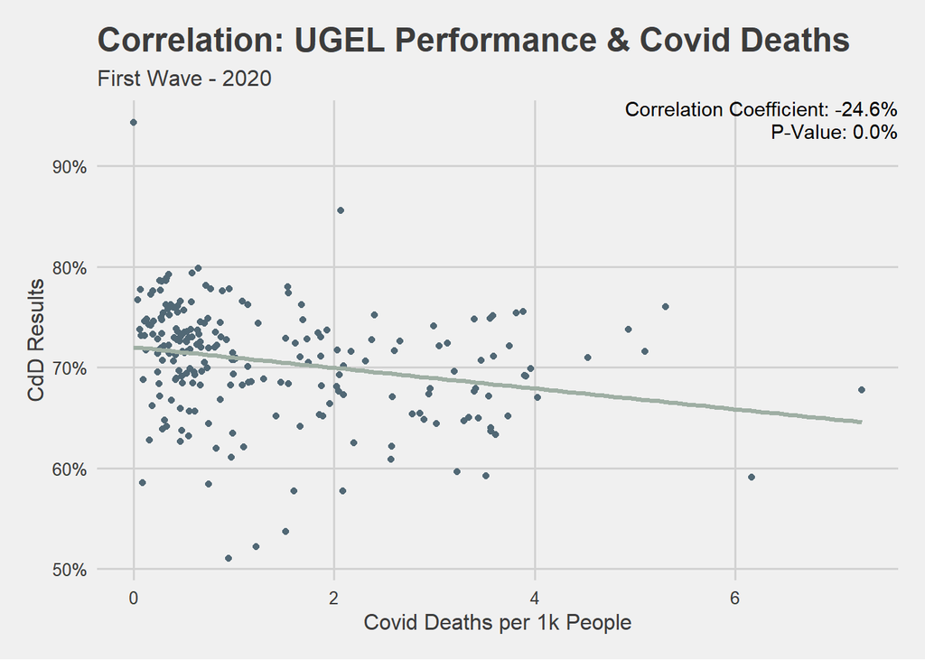

```r
cor_2020 <- cor.test(df_2020$covid_deaths_2020_2_3, df_2020$vl_2020_2_3)


#Visualization
corr_2020_chart <- df_2020 %>%
  ggplot(aes(x = covid_deaths_2020_2_3,y=vl_2020_2_3)) +
  geom_point(color = "#516875") +
  geom_smooth(method = "lm", se = FALSE,color = "#9fafa4",size=1.2) +
  theme_fivethirtyeight() +
  labs(title = "Correlation: UGEL Performance & Covid Deaths", subtitle = "First Wave - 2020") +
  annotate("text", x = Inf, y = Inf, label = paste0("Correlation Coefficient: ",
                                                    paste0(scales::percent(cor_2020$estimate, accuracy = 0.1))),
           hjust = 1, vjust = 1) +
  annotate("text", x = Inf, y = Inf, label = paste0("P-Value: ",
                                                    paste0(scales::percent(cor_2020$p.value, accuracy = 0.1))),
           hjust = 1, vjust = 2.5) +
  scale_y_continuous(labels = percent_format(accuracy = 1)) +
  theme(axis.title = element_text()) + ylab("CdD Results") + xlab("Covid Deaths per 1k People")

corr_2020_chart
```

```r
ggsave("corr_2020_chart.png", plot = corr_2020_chart, width = 8, height = 5, dpi = 300)
```

### Second Wave of Covid-19 in Peru (1st and 2nd quarters of 2021)

Based on the data analyzed, it seems that the second wave of Covid-19 related deaths in Peru may not be significantly correlated with UGEL performance, as the p-value is higher than .25. This could be an indication that institutions have become better adapted to the pandemic after a year of experience, and other factors may be contributing to the performance hit.

```r
#2021 subset
df_2021 <- analysis_df %>%
  mutate(covid_deaths_2021_1_2 = covid_deaths_2021_1 + covid_deaths_2021_2) %>%
  filter(!is.na(vl_2021_1_2)) %>%
  select(vl_2021_1_2,covid_deaths_2021_1_2)

#Correlation test
cor(df_2021)
```

```
##                       vl_2021_1_2 covid_deaths_2021_1_2
## vl_2021_1_2            1.00000000            0.07438889
## covid_deaths_2021_1_2  0.07438889            1.00000000
```

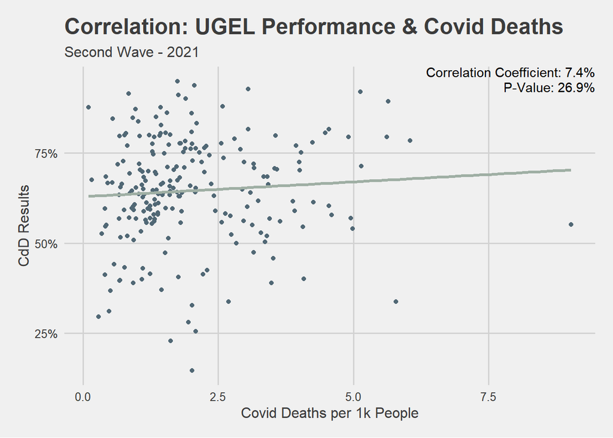

```r
cor_2021 <- cor.test(df_2021$covid_deaths_2021_1_2, df_2021$vl_2021_1_2)


#Visualization
corr_2021_chart <- df_2021 %>%
  ggplot(aes(x = covid_deaths_2021_1_2,y=vl_2021_1_2)) +
  geom_point(color = "#516875") +
  geom_smooth(method = "lm", se = FALSE,color = "#9fafa4",size=1.2) +
  theme_fivethirtyeight() +
  labs(title = "Correlation: UGEL Performance & Covid Deaths", subtitle = "Second Wave - 2021") +
  annotate("text", x = Inf, y = Inf, label = paste0("Correlation Coefficient: ",
                                                    paste0(scales::percent(cor_2021$estimate, accuracy = 0.1))),
           hjust = 1, vjust = 1) +
    annotate("text", x = Inf, y = Inf, label = paste0("P-Value: ",
                                                    paste0(scales::percent(cor_2021$p.value, accuracy = 0.1))),
           hjust = 1, vjust = 2.5) +
  scale_y_continuous(labels = percent_format(accuracy = 1)) +
  theme(axis.title = element_text()) + ylab("CdD Results") + xlab("Covid Deaths per 1k People")

corr_2021_chart
```

```r
ggsave("corr_2021_chart.png", plot = corr_2021_chart, width = 8, height = 5, dpi = 300)
```

### Covid-19 Hit on Performance During the 1st Wave

Based on the analysis conducted, it appears that there was a correlation between the impact of Covid-19 on each jurisdiction and the reduced performance of the UGELs in those jurisdictions during the first wave of the pandemic. Although, this correlation seems to be less evident in this case, and there might be other factors in play.

```r
#2021 subset
df_2020_hit <- analysis_df %>%
  mutate(covid_deaths_2020_2_3 = covid_deaths_2020_2 + covid_deaths_2020_3,
         vl_2020_dif =  vl_2020_2_3 - vl_2020_1) %>%
  filter(!is.na(vl_2020_dif)) %>%
  select(vl_2020_dif,covid_deaths_2020_2_3)

#Correlation test
cor(df_2020_hit)
```

```
##                       vl_2020_dif covid_deaths_2020_2_3
## vl_2020_dif             1.0000000            -0.1068479
## covid_deaths_2020_2_3  -0.1068479             1.0000000
```

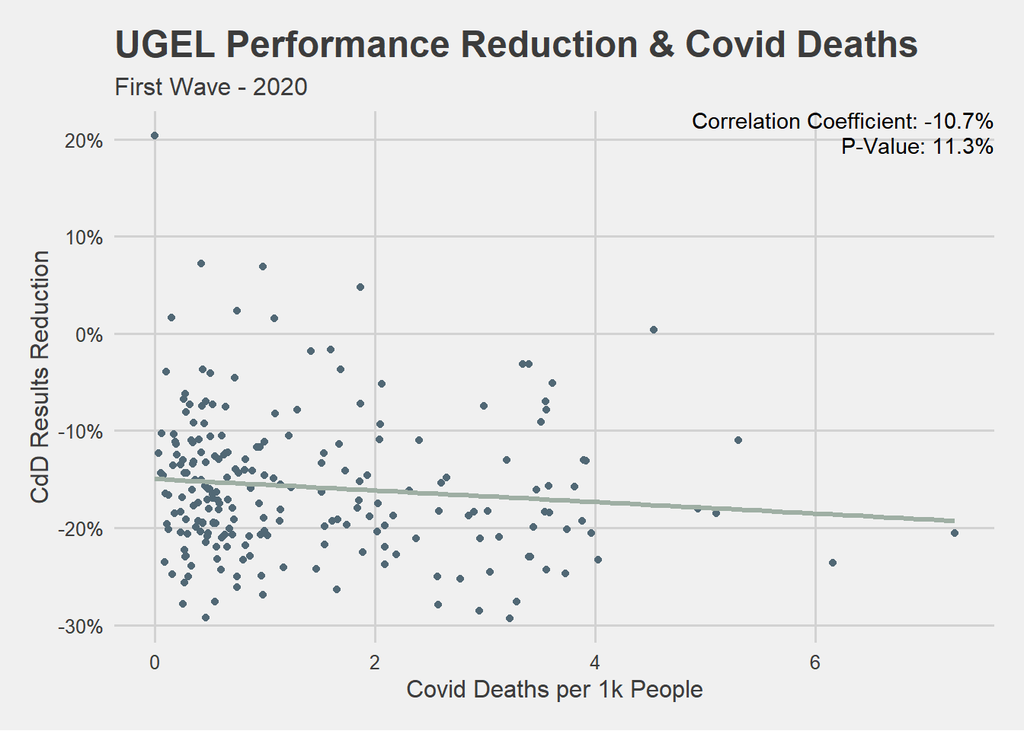

```r
cor_2020_hit <- cor.test(df_2020_hit$covid_deaths_2020_2_3, df_2020_hit$vl_2020_dif)


#Visualization
corr_2020hit_chart <- df_2020_hit %>%
  ggplot(aes(x = covid_deaths_2020_2_3,y=vl_2020_dif))+
  geom_point(color = "#516875") +
  geom_smooth(method = "lm", se = FALSE,color = "#9fafa4",size=1.2) +
  theme_fivethirtyeight() +
  labs(title = "UGEL Performance Reduction & Covid Deaths", subtitle = "First Wave - 2020") +
  annotate("text", x = Inf, y = Inf, label = paste0("Correlation Coefficient: ",
                                                    paste0(scales::percent(cor_2020_hit$estimate, accuracy = 0.1))),
           hjust = 1, vjust = 1) +
    annotate("text", x = Inf, y = Inf, label = paste0("P-Value: ",
                                                    paste0(scales::percent(cor_2020_hit$p.value, accuracy = 0.1))),
           hjust = 1, vjust = 2.5) +
  scale_y_continuous(labels = percent_format(accuracy = 1)) +
  theme(axis.title = element_text()) + ylab("CdD Results Reduction") + xlab("Covid Deaths per 1k People")

corr_2020hit_chart
```

```r
ggsave("corr_2020hit_chart.png", plot = corr_2020hit_chart, width = 8, height = 5, dpi = 300)
```

## Linear regression analysis.

Linear regressions are a powerful statistical tool that can help analyze the impact of other factors, other than Covid-19, that affected UGELs performance on the CdD program. By using regression models, we can estimate the relationships between different variables in different jurisdictions. This approach can provide a more comprehensive analysis of the underlying factors that influenced institutional performance during the pandemic.

In the first model, we can observe that Covid-19 related deaths had a significant impact on UGELs performance during the first wave in 2020, but the effect was reduced during the third quarter of that year. Additionally, the number of students had a significant but small impact on CdD results.

In the second model, we found that the impact of Covid-19 on UGELs performance during the second wave in Peru was not as significant as during the first wave in 2020. However, the model revealed some interesting and somewhat contradictory results, as it showed that Covid-19 related deaths in the 2nd quarter and rurality had a positive impact on UGELs performance. One possible explanation could be that urban areas had multiple lockdowns mandates enforced by the government relative and that could have hinder the results of the UGELs. However it is important to conduct more research to fully understand the underlying factors contributing to these results.

Finally, the third model may indicate that, although this analysis may be headed on the right path, further analysis may be needed to finally understand how Covid-19 effected UGELs performance. None of the variables selected explain the reduction in achievement value between phase 1 of the CdD 2020 and phases 2 and 3 of the same year.

```r
head(analysis_df)
```

```
## # A tibble: 6 × 26
##   codooii ugel   vl_2020_1 vl_2020_2 vl_2020_2_3 vl_2020_4 vl_2021_1_2 vl_2021_3
##     <dbl> <chr>      <dbl>     <dbl>       <dbl>     <dbl>       <dbl>     <dbl>
## 1   10001 UGEL …     0.838     0.37        0.620   NaN           0.725     0.646
## 2   10002 UGEL …     0.923     0.675       0.721     0.969       0.860     0.683
## 3   10003 UGEL …     0.919     0.368       0.626   NaN           0.703     0.678
## 4   10004 UGEL …     0.767     0.701       0.689     0.986       0.546     0.628
## 5   10005 UGEL …     0.868     0.388       0.639   NaN           0.4       0.602
## 6   10006 UGEL …     0.875     0.368       0.627   NaN           0.746     0.78
## # ℹ 18 more variables: covid_deaths_2020_1 <dbl>, covid_deaths_2020_2 <dbl>,
## #   covid_deaths_2020_3 <dbl>, covid_deaths_2020_4 <dbl>,
## #   covid_deaths_2021_1 <dbl>, covid_deaths_2021_2 <dbl>,
## #   covid_deaths_2021_3 <dbl>, covid_deaths_2021_4 <dbl>, covid_deaths <int>,
## #   population <int>, region <chr>, n_students <dbl>, rural_strudents <dbl>,
## #   rurality <dbl>, mean_elevation_msnm <dbl>, n_schools <int>,
## #   prcnt_andes <dbl>, prcnt_selva <dbl>
```

```r
analysis_df_scaled <- analysis_df %>%
  select(-c(ugel,region)) %>%
  as.data.frame(scale())

#First pandemic wave: 2020

model_2020 <- lm(vl_2020_2_3 ~ covid_deaths_2020_2 + covid_deaths_2020_3 + n_students + rurality,
                 data = analysis_df_scaled)


#Second pandemic wave: 2021
model_2021 <- lm(vl_2021_1_2 ~ covid_deaths_2021_1 + covid_deaths_2021_2 + n_students + rurality,
                 data = analysis_df_scaled)

#First pandemic hit on performance
df_2020_hit_full <- analysis_df %>%
  mutate(vl_2020_dif =  vl_2020_2_3 - vl_2020_1) %>%
  select(-c(ugel,region)) %>%
  as.data.frame(scale())
model_2020_hit <- lm(vl_2020_dif ~ covid_deaths_2020_2 + covid_deaths_2020_3 + n_students + rurality,
                 data = df_2020_hit_full)


#Models summary
summary(model_2020)
```

```
##
## Call:
## lm(formula = vl_2020_2_3 ~ covid_deaths_2020_2 + covid_deaths_2020_3 +
##     n_students + rurality, data = analysis_df_scaled)
##
## Residuals:
##       Min        1Q    Median        3Q       Max
## -0.195126 -0.027096  0.005527  0.029744  0.228515
##
## Coefficients:
##                       Estimate Std. Error t value Pr(>|t|)
## (Intercept)          7.193e-01  1.341e-02  53.649  < 2e-16 ***
## covid_deaths_2020_2 -2.104e-02  6.231e-03  -3.377 0.000868 ***
## covid_deaths_2020_3  5.889e-03  5.475e-03   1.076 0.283299
## n_students          -1.621e-07  7.913e-08  -2.049 0.041661 *
## rurality            -3.375e-03  1.646e-02  -0.205 0.837773
## ---
## Signif. codes:  0 '***' 0.001 '**' 0.01 '*' 0.05 '.' 0.1 ' ' 1
##
## Residual standard error: 0.05173 on 216 degrees of freedom
##   (2 observations deleted due to missingness)
## Multiple R-squared:  0.1329, Adjusted R-squared:  0.1169
## F-statistic:  8.28 on 4 and 216 DF,  p-value: 3.127e-06
```

```r
summary(model_2021)
```

```
##
## Call:
## lm(formula = vl_2021_1_2 ~ covid_deaths_2021_1 + covid_deaths_2021_2 +
##     n_students + rurality, data = analysis_df_scaled)
##
## Residuals:
##      Min       1Q   Median       3Q      Max
## -0.46622 -0.08222  0.00823  0.09847  0.32690
##
## Coefficients:
##                       Estimate Std. Error t value Pr(>|t|)
## (Intercept)          5.480e-01  4.463e-02  12.279   <2e-16 ***
## covid_deaths_2021_1  5.000e-03  2.508e-02   0.199   0.8422
## covid_deaths_2021_2  5.030e-02  2.417e-02   2.082   0.0386 *
## n_students          -2.109e-07  2.204e-07  -0.957   0.3397
## rurality             8.873e-02  4.783e-02   1.855   0.0649 .
## ---
## Signif. codes:  0 '***' 0.001 '**' 0.01 '*' 0.05 '.' 0.1 ' ' 1
##
## Residual standard error: 0.144 on 218 degrees of freedom
## Multiple R-squared:  0.0464, Adjusted R-squared:  0.0289
## F-statistic: 2.652 on 4 and 218 DF,  p-value: 0.03413
```

```r
summary(model_2020_hit)
```

```
##
## Call:
## lm(formula = vl_2020_dif ~ covid_deaths_2020_2 + covid_deaths_2020_3 +
##     n_students + rurality, data = df_2020_hit_full)
##
## Residuals:
##      Min       1Q   Median       3Q      Max
## -0.13957 -0.05036 -0.01245  0.03843  0.34862
##
## Coefficients:
##                       Estimate Std. Error t value Pr(>|t|)
## (Intercept)         -1.587e-01  1.884e-02  -8.422 5.17e-15 ***
## covid_deaths_2020_2  9.090e-03  8.758e-03   1.038   0.3005
## covid_deaths_2020_3 -4.767e-03  7.696e-03  -0.619   0.5362
## n_students          -2.100e-07  1.112e-07  -1.889   0.0603 .
## rurality             1.546e-02  2.314e-02   0.668   0.5047
## ---
## Signif. codes:  0 '***' 0.001 '**' 0.01 '*' 0.05 '.' 0.1 ' ' 1
##
## Residual standard error: 0.07271 on 216 degrees of freedom
##   (2 observations deleted due to missingness)
## Multiple R-squared:  0.03684,    Adjusted R-squared:  0.019
## F-statistic: 2.065 on 4 and 216 DF,  p-value: 0.08642
```

# Consclusions and recommendations

In conclusion, our research highlights the significant impact that the first wave of Covid-19 had on UGELs performance in Peru in 2020, particularly in areas that were hit harder by the pandemic. However, our analysis of the second wave in 2021 suggests that institutions may have adapted to the pandemic, and that there may have been underlying factors contributing to performance reduction.

While our findings provide some insights into the effects of Covid-19 on UGELs performance, more research is needed to fully understand the underlying factors contributing to these changes. Further research could include exploring individual indicators evaluated during 2019, 2020, and 2021 to identify trends related to Covid-19 impact on UGELs performance, and incorporating other variables into the linear regression models, such as health access and income in the jurisdiction.

# Appendix

## Public Education in Peru

The public education sector in Peru has the particularity of being divided into more than 220 decentralized institutions called “UGEL” (Unidades de Gestión Educativa Local) with similar functions and responsibilities for supplying public education throughout their individual jurisdictions. For further information on this topic, please refer to Article 73 of the Law 28044 (http://www.minedu.gob.pe/p/ley_general_de_educacion_28044.pdf). As part of the CdD Program, Minedu assesses various Key Performance Indicators for each UGEL, and the historical results from 2014 to the present day are publicly available on the CdD website (http://www.minedu.gob.pe/cdd/).